# Exceso de mortalidad en Ecuador

PBG

31/12/2020

Este análisis busca explorar el exceso de mortalidad como aproximación de medición de la pandemia de COVID 19 en el Ecuador. Se basa en datos de fuentes públicas: defunciones y elementos geográficos. También aporta unos elementos de reflexión sobre las limitaciones para estimar el impacto de la pandemia con este método. Se encuentra en [este](https://github.com/PBG-Ec/COVID_EC) repositorio el código/datos de análisis, usando R & Rmarkdown (cran-R 4.0.2 y Rstudio 1.3).  
Esta en parte basado sobre el excelente material publicado de Roser et al.[1](https://ourworldindata.org/excess-mortality-covid).

Fuentes de datos:  
*(1) Informaciones de defunciones generales 2016-2019 publicadas por el INEC: los datos se encuentran* [ahí](https://www.ecuadorencifras.gob.ec/defunciones-generales-2019/) y [aca](https://www.ecuadorencifras.gob.ec/nacimientos-y-defunciones-informacion-historica/).*  
*(2) Informaciones de defunciones 2020 publicadas por el registro civil se encuentran actualizadas* [ahí](https://www.registrocivil.gob.ec/cifrasdef/)  
*(3) Datos geográficos empleados para realizar mapas se encuentran en el repositorio del INEC* [ahí](https://www.ecuadorencifras.gob.ec/geoportal/) *y bases del clasificador de divisiones político administrativas* [acá](https://www.ecuadorencifras.gob.ec/clasificador-geografico-estadistico-dpa/) **

_*La información mas completa se encuentra en formato .sav, con etiquetas de las variables_  
_**El sitio se encuentra actualmente en mantenimiento (al martes de 31 de diciembre) intente: [acá](https://www.ecuadorencifras.gob.ec/documentos/web-inec/Cartografia/Clasificador_Geografico/CLASIFICADOR_GEOGRAFICO_ESTADISTICO_2019.zip)_

*Póngase en contacto si encuentra algo extraño y/o interesante. Abra un problema en Github o escriba a ldsfelipe [aroba] gmail.com ¡Gracias!*

# ‘Exceso de mortalidad’ Que es ? Porque medirlo ? Como se mide ?

Se refiere en epidemiología al número de muertes (todas causas confundidas) por encima o por debajo de lo esperado comparado con un periodo “normal”. Con la información disponible veremos como estimarla sobre distintos intervalos de tiempo, desde el comienzo de la pandemia.

Esta medición, provee un estimado del impacto “total” de una crisis, sin distinción de la causa de muerte. El exceso estimado suma a las muertes por COVID-19, muertes por otras causas igualmente atribuibles a las condiciones de la crisis (p.e. falta de acceso a establecimientos de salud, movilidad restringida en periodos de confinamiento). Este indicador refleja el impacto del avance de la pandemia y complementa información obtenida con campañas de test.

La medida del exceso mortalidad (EM) es igual a la diferencia entre el número de muertos (M) en un periodo de crisis y el promedio del número de muertos (PM) durante un mismo periodo de referencia. Sin embargo, para permitir comparaciones, se usa aqui el *P-score* que refleja la diferencia porcentual entre muertes en 2020 y muertes en el periodo de referencia (ilustrado con t(i)):

$$P-score=\frac{M_{t(i)}-PM_{t(i)}}{PM_{t(i)}} *100$$

# Resolución y limitación

Datos de exceso de mortalidad a nivel nacional y por provincia han sido reportados, no siempre actualizados o mas desagregados [ahí](https://www.economist.com/graphic-detail/2020/07/15/tracking-covid-19-excess-deaths-across-countries) y [acá](https://www.nytimes.com/interactive/2020/04/21/world/coronavirus-missing-deaths.html) y [acá](https://www.ft.com/content/a2901ce8-5eb7-4633-b89c-cbdf5b386938). Queremos probar aquí si resulta factible y útil estudiar el fenómeno de exceso de mortalidad a nivel de parroquias, nivel de desagregación más alto reportado.No se reporta Galápagos por el momento.

La información actualizada de defunciones presenta dos problemas:  
- no reporta la codificación numérica de división político administrativa (DPA), solo cadena de texto como “nombre” de la parroquia,  
- ademas, reporta las defunciones por parroquias urbanas (sub-división de las parroquias cabeceras cantonales), que presentan sinónimos con los nombres de parroquias no urbanas.

# Codificación de parroquias para comparación inter-anual

Comparando las bases de datos de 2020 con la referencia oficial de DPA (clasificador estadístico 2019) podemos unificar cadenas de texto original con las designación del registro civil (comparación aproximada de cadenas de texto). Para evitar los nombres duplicados, se realizan las comparaciones dentro de cada cantón (después de depuración de estas cadenas de texto).  
Aún así, surgen problemas de empate cuando las parroquias contienen parroquias urbanas, y tienen una parroquia urbana con el mismo nombre que la parroquia “cabecera de cantón” (más a continuación).

## Clasificador DPA 2019

Los datos del clasificador 2019 (“CODIFICACIÓN_2019.xlsx” descargado [ahí](https://www.ecuadorencifras.gob.ec/documentos/web-inec/Cartografia/Clasificador_Geografico/CLASIFICADOR_GEOGRAFICO_ESTADISTICO_2019.zip) ) incluyen las parroquias urbanas. Las parroquias urbanas son subdivisiones de las Parroquias Cabeceras Cantonales (PCC). Sin embargo, oficialmente la geografía de las sub-unidades urbanas no están siempre geograficamente definidas.

| pro_n | pro | can_n | can | par_n | par | par_n_o | par_o |
| --- | --- | --- | --- | --- | --- | --- | --- |
| 01 | AZUAY | 0101 | cuenca | 010101 | bellavista | 010150 | CUENCA |
| 01 | AZUAY | 0101 | cuenca | 010102 | canaribamba | 010150 | CUENCA |
| 01 | AZUAY | 0101 | cuenca | 010103 | el batan | 010150 | CUENCA |
| 01 | AZUAY | 0101 | cuenca | 010104 | el sagrario | 010150 | CUENCA |
| 01 | AZUAY | 0101 | cuenca | 010105 | el vecino | 010150 | CUENCA |
| 01 | AZUAY | 0101 | cuenca | 010106 | gil ramirez davalos | 010150 | CUENCA |

## Defunciones 2020

Las bases publicadas de defunción se unificaron siguiendo tres etapas:  
- nombres de cantones (manual), - empate aproximado difuso de cadenas de texto por cantones, - unión de las bases para obtener el código DPA actualizado (2019)

Las parroquias urbanas de una ciudad no cubren por completo la extensión de las PCCs y muertes ocurridas en “parroquias cabeceras cantonales” se encontrarían en estos espacios de geografía no cubiertas por las extensiones de parroquias urbanas.

Finalmente, para algunos casos, los nombres de las parroquias urbanas son homónimos (tocayos) de las PCCs al cual pertenecen, dejando irresuelta la geografía de estas unidades. Al tener resolución exacta para nombre de PCCs en las ciudades mas grandes, y *ausencia de partes no “urbanas” en la base de defunciones 2020*, no se procederá a resolver este problema y se asigna por defecto los números correspondientes a las parroquias urbanas.

|  | pro | can_n | par_n | pao_n | par_o | fec |
| --- | --- | --- | --- | --- | --- | --- |
| 246 | AZUAY | 0101 | 010101 | 010150 | bellavista | 2020-11-21 |
| 247 | AZUAY | 0101 | 010101 | 010150 | bellavista | 2020-04-01 |
| 248 | AZUAY | 0101 | 010101 | 010150 | bellavista | 2020-09-03 |
| 249 | AZUAY | 0101 | 010101 | 010150 | bellavista | 2020-09-11 |
| 250 | AZUAY | 0101 | 010101 | 010150 | bellavista | 2020-05-26 |
| 251 | AZUAY | 0101 | 010101 | 010150 | bellavista | 2020-08-18 |

# Defunción histórica

|  | par_n | pao_n | anio_nac | fec |
| --- | --- | --- | --- | --- |
| 3808 | 010101 | 010150 | 1964 | 2018-01-10 |
| 4186 | 010101 | 010150 | 1941 | 2018-01-05 |
| 5638 | 010101 | 010150 | 1936 | 2018-04-05 |
| 5639 | 010101 | 010150 | 1939 | 2018-05-05 |
| 5736 | 010101 | 010150 | 1953 | 2018-02-12 |
| 5783 | 010101 | 010150 | 1927 | 2018-02-02 |

Se nota aquí que partes no urbanas de las PCCs faltan en algunos casos al realizar la unión entre defunción 2020 y datos históricos cuando los nombres son sinónimos.

# Información geográfica

Como mencionado anteriormente, los datos de división político administrativa a nivel de parroquias están definidos geograficamente, sin embargo no existe oficialmente delimitaciones geográficas de parroquias urbanas.

Juntando información publicada por municipios, estudios geográficos locales y codificación existente de “zonas” del INEC se realizo una codificación aproximada en base a las unidades de “zonas” urbanas definidas por el INEC, que en muchos casos corresponden en extensión a las definidas por los municipios. Un ejemplo aquí entre las parroquias reportadas en la página wikipedia sobre Quito (https://es.wikipedia.org/wiki/Quito) al a izquierda y las divisiones de grupos de zonas del INEC a la derecha.

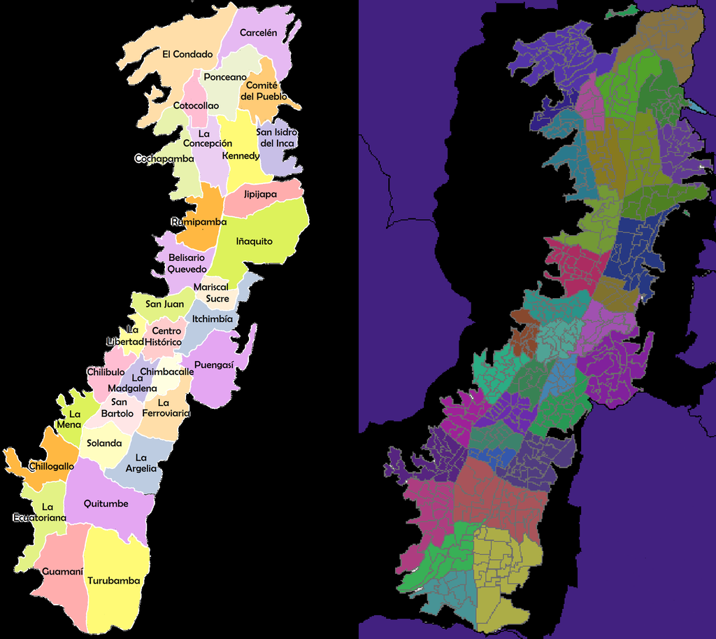

Aquí el área en negro (derecha), corresponde a las extensiones de la Parroquia “Quito” que no cubren las parroquias urbanas y deberían tener registros en la base 2020. La correspondencia de códigos se encuentra en el archivo dpa_2019_parrURB_fin.xlsx en github.

Uniendo estas entidades geográficas “urbanas” se obtienen mapas tanto a nivel de parroquias como de “ciudades” definidas por parroquias urbanas. Aquí un ejemplo con el cantón Quito.

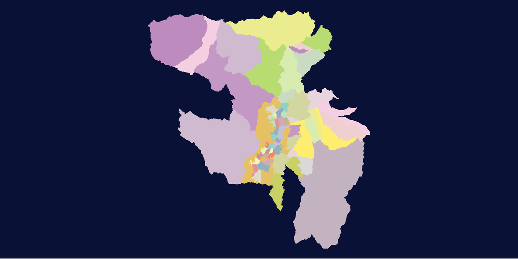

# Aggregación de datos

Solo falta unificar la información de defunción a la resolución deseada y realizar el cálculo de exceso de mortalidad por entidades reportadas.

Aparecen varios casos particulares el en calculo de exceso de mortalidad donde:  
- no existen muertes en la entidad en los datos históricos o en 2020, - el exceso por encima de 200 % fue acortado como máximo a 200 %.

## Resumen de exceso de mortalidad por provincias / parroquias

Observado el exceso de muertes por provincia y meses, se nota que primero y en mayor magnitud fue afectada la costa, donde parece haber “iniciado” la pandemia, en menor magnitud la sierra y la región amazónica.

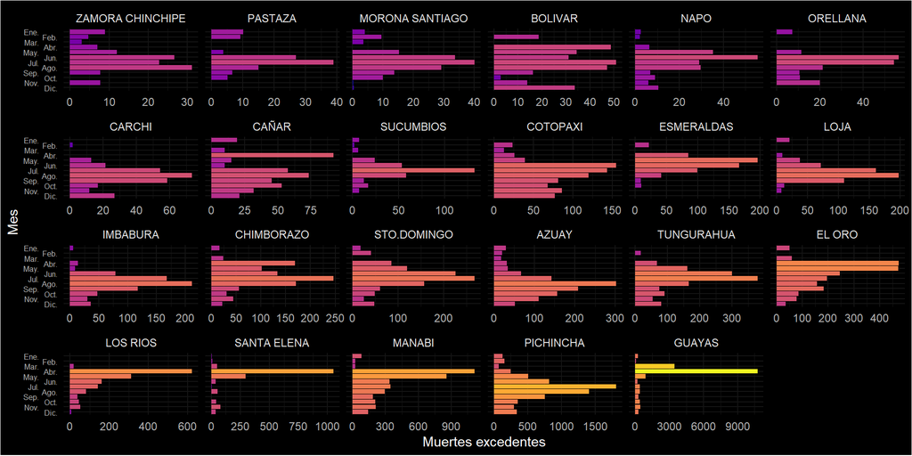

A nivel de exceso “relativo” (p-score) podemos observar que las provincias llegaron a un exceso “máximo” hasta el mes de agosto y septiembre, con una baja de las muertes excedentes después de estos meses.

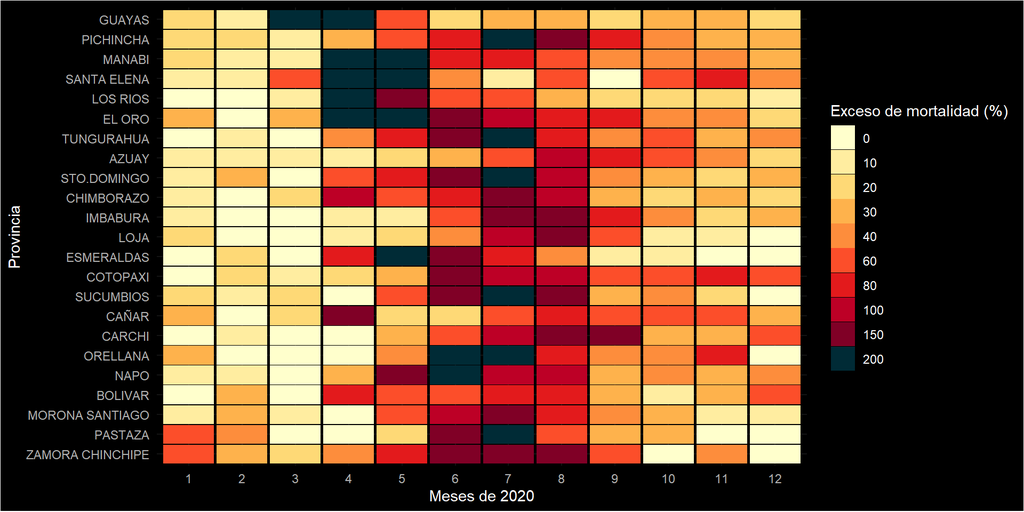

En el mes de diciembre, los niveles de exceso de mortalidad pueden ser más reducidos, sin embargo, *las declaraciones de defunción tienden a ser incompletas en las últimas fechas reportadas*, con declaraciones para el último mes ocurriendo los meses siguientes.

Con la información compilada, los mapas de exceso de mortalidad dan una idea de la difusión de la pandemia mes a mes:

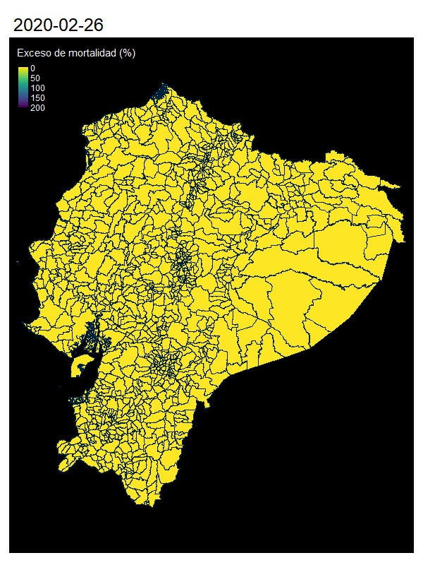

U observado la evolución por provincias (Guayas a la izquierda), o dentro de un cantón (Quito a la derecha).

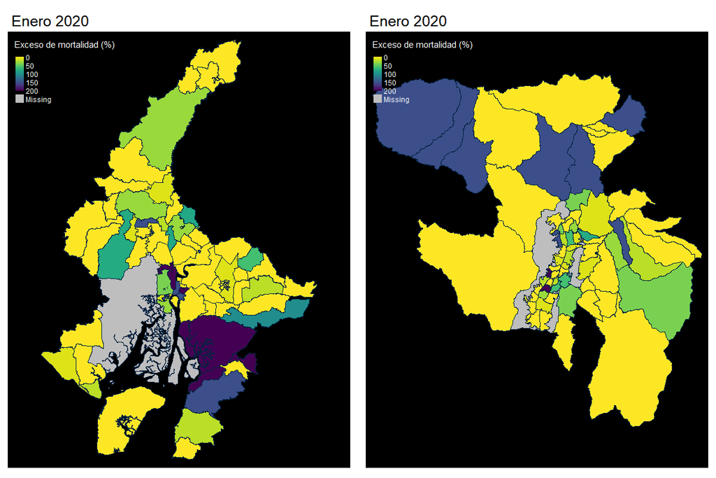

Se podría realizar un ajuste por población proyectada, en vista de comparar tasas de excesos de muertes de periodo de referencia, y obtener comparaciones mas precisas comparando con el periodo 2020-2021…

# Referencias:

[1] Max Roser, Hannah Ritchie, Esteban Ortiz-Ospina and Joe Hasell (2020) - “Coronavirus Pandemic (COVID-19)”. Published online at OurWorldInData.org. Retrieved from: ‘https://ourworldindata.org/coronavirus’ [Online Resource]